# Radial intensity analysis

Tom van Schaik

29 July, 2019

### Setup

Load the required libraries.

```r
# Load libraries
library(pixmap)   ## read.pnm(..)
library(ggplot2)
library(reshape2)
library(ggbeeswarm)

# Prepare output directory
output_dir <- "ts190729_radial_intensity_analysis"
dir.create(output_dir, showWarnings = FALSE)

image_dir <- file.path(output_dir, "images")
dir.create(image_dir, showWarnings = FALSE)
```

```r
library(knitr)
opts_chunk$set(dev=c('png', 'pdf'), fig.path = file.path(output_dir, "figures/"))
pdf.options(useDingbats = FALSE)
```

```r
ReadPGNFromDF <- function(df, i, target) {

  # Get file name
  f <- file.path(image.path,
                 paste0(df$names[i], "_",
                        target,
                        ".pgm"))

  # Get image, only grey values
  suppressWarnings(read.pnm(f)@grey*255)

}

GetSignalPerLayer <- function(target, dist.factor, f = sum, q = 0.2) {

      # Get total signal per layer
      pixellayer <- unlist(tapply(target, dist.factor, f, simplify=FALSE))

      # To normalize, subtract background & normalize to 0..1
      d.zero <- quantile(pixellayer, q)
      pixellayer.norm <- pixellayer - d.zero
      pixellayer.norm <- pixellayer.norm / max(pixellayer.norm)

      # Area per pixel layer
      pixellayer.area <- table(dist.factor)
      pixellayer.area <- pixellayer.area[pixellayer.area > 0]

      list(pixellayer = pixellayer,
           pixellayer.norm = pixellayer.norm,
           pixellayer.area = pixellayer.area)

}

TrimMean <- function(x, trim = 0.2) {
  if (length(x) < 3) {
    trim = 0
  }
  y <- x[x >= quantile(x, c(trim)) & x <= quantile(x, c(1 - trim))]
  mean(y)
}

GetHalfwayPoint <- function(d, d.zero, x.max = 40) {

  # First, I want to find the lower bound to 0
  # d.zero <- quantile(d, 0.2)

  # Then, I want to get rid of the peak itself
  d.subset <- d[1 : (x.max + 5)]

  d.max <- which(d.subset > 0.95 * max(d.subset))
  d.max <- as.vector(d.max[length(d.max)])
  #d.subset <- d[(d.max + 1) : length(d)]
  d.subset <- d.subset[(d.max + 1) : length(d.subset)]

  # Fit exponential decay function
  z <- nls(y ~ SSasymp(x, yf, y0, log_alpha),
           data = data.frame(x = seq_along(d.subset),
                             y = as.vector(d.subset)))

  lines(seq_along(d.subset) + d.max, predict(z, seq_along(d.subset)),
        col = "black", lty = 2)

  # Then, what is the halfway value?
  d50 <- mean(c(d.zero, max(d)))

  # Can we get this value?
  d50.pix <- approx(x = predict(z), y = seq_along(d.subset) + d.max, xout = d50)$y
  points(d50.pix, d50, col = "black", pch = 19, cex = 2)

  # Finally, correct the d50 value for d.zero
  # d50 <- d50 + d.zero

  return(list(d50 = d50, d50.pix = d50.pix))

}

RadialProfile <- function(data.per.pix, ref.per.pix, area.per.pix, exp.name,
                          dapi.per.pix, lam.per.pix,
                          xlim = c(0, 40), unit = "pixel") {

  # profile plot of a signal
  ########################################################################
  if(missing(data.per.pix))
    stop('argument data.per.pix missing')
  if(missing(area.per.pix))
    stop('argument area.per.pix missing')

  # Use shorter names
  d <- data.per.pix

  if (missing(dapi.per.pix) == FALSE & missing(lam.per.pix) == FALSE) {
    l <- lam.per.pix
    da <- dapi.per.pix
  }

  ### set up plot
  xlab <- paste0("Distance from nuclear rim (", unit, ")")
  ylab <- 'average signal'
  ylim <- c(0, max(c(d)))
  title <- sprintf('profile per %s; %s', unit, exp)

  plot(NA, xlim=xlim, ylim=ylim, xlab=xlab, ylab=ylab,
       ty='o', pch=19, lwd=2, main=title)
  lines(d, col='red', ty='o', pch=19, lwd=2, cex=.5)

  if (missing(dapi.per.pix) == FALSE & missing(lam.per.pix) == FALSE) {
    # lines(da, col='blue', ty='o', pch=19, lwd=2, cex=.5)
    lines(l, col='green', ty='o', pch=19, lwd=2, cex=.5)
  }

  # At which pixel do we observe the half-max value, with what value?
  d.zero <- quantile(d, 0.2)
  halfway <- GetHalfwayPoint(d, d.zero = d.zero, x.max = 15)
  d50 <- halfway[["d50"]]
  d50.pix <- halfway[["d50.pix"]]

  # Repeat this exercise for the lamina
  if (missing(lam.per.pix) == FALSE) {
    l.zero <- quantile(l, 0.2)
    l.halfway <- GetHalfwayPoint(l, d.zero = l.zero, x.max = 15)
    l.d50 <- l.halfway[["d50"]]
    l.d50.pix <- l.halfway[["d50.pix"]]
  }

  # draw lines indicating the d50 values
  lines(x=c(d50.pix, d50.pix), y=c(d50, -1), lty=2, lwd=2, col='grey')
  lines(x=c(l.d50.pix, l.d50.pix), y=c(l.d50, -1), lty=2, lwd=2, col='grey')

  # make legend
  col <- c('red','grey')
  lty <- 1:2
  legend <- c('signal', sprintf('half-max (pixel=%.2f, p50=%.4f)', d50.pix, d50))

  if (missing(dapi.per.pix) == FALSE & missing(lam.per.pix) == FALSE) {
    # col <- c('red', 'blue', 'green', 'grey', 'grey')
    # lty <- c(1, 1, 1, 2, 2)
    # legend <- c('tracer', 'dapi', 'lamina',
    #             sprintf('half-max tracer (pixel=%.2f, p50=%.4f)', d50.pix, d50),
    #             sprintf('half-max lamina (pixel=%.2f, p50=%.4f)', l.d50.pix, l.d50))
    col <- c('red', 'green', 'grey', 'grey')
    lty <- c(1, 1, 2, 2)
    legend <- c('tracer', 'lamina',
                sprintf('half-max tracer (pixel=%.2f, p50=%.4f)', d50.pix, d50),
                sprintf('half-max lamina (pixel=%.2f, p50=%.4f)', l.d50.pix, l.d50))
  } else {
    col <- c('red','grey')
    lty <- 1:2
    legend <- c('signal', sprintf('half-max (pixel=%.2f, p50=%.4f)', d50.pix, d50))
  }

  legend(x='topr', inset=0.025, bty='n', col=col, lwd=2, lty=lty, legend=legend)
  ret.list <- list(d50 = d50, d50.pix = d50.pix,
                   l.d50 = l.d50, l.d50.pix = l.d50.pix)


  # save m.50 values to file
  return(ret.list)
}
```

### Radial profiles

```r
image.paths <- as.character(c("ts190729_processed_images/ts190221_HTC75_DamID_m6Tracer_analysis/",
                              "ts190729_processed_images/mv190314_pADam_analysis/",
                              "ts190729_processed_images/ts190411_HTC75_analysis/"))
image.paths <- normalizePath(image.paths)

################################################################################
# MAIN #########################################################################
################################################################################

# loop over the three directories containing images
exp.res <- list()

for (image.path in image.paths) {

  # Get image path
  image.path.short <- basename(image.path)

  cat('Processing images in', image.path, '\n')

  # init results list
  exp.res[[ image.path]] <- list()

  # List experiments
  experiments <- dir(path=image.path, pattern='segmentation')
  experiments.names <- gsub("_segmentation.pgm", "", experiments)

  experiments.df <- data.frame(files = experiments,
                               names = experiments.names,
                               stringsAsFactors = FALSE)

  experiments.df$target <- sapply(experiments.df$names,
                                  function(x) strsplit(x, "_")[[1]][2])
  experiments.df$plate <- sapply(experiments.df$names,
                                 function(x) strsplit(x, "_")[[1]][3])
  experiments.df$cell <- sapply(experiments.df$names,
                                function(x) strsplit(x, "_")[[1]][1])

  experiments.df$sample <- gsub("_\\d+_\\d+", "", experiments.df$names)

  exp.res[[ image.path]][["experiments.df"]] <- experiments.df


  # Loop over experiments
  for (i in 1:nrow(experiments.df)) {

    exp <- experiments.df$names[i]

    # Read images
    mask <- ReadPGNFromDF(experiments.df, i, "segmentation")
    dist <- ReadPGNFromDF(experiments.df, i, "distancemap")
    dapi <- ReadPGNFromDF(experiments.df, i, "DAPI")
    lamina <- ReadPGNFromDF(experiments.df, i, "lamina")
    tracer <- ReadPGNFromDF(experiments.df, i, "tracer")

    # check that distance map is using correct pixel values
    # If not, invert the values
    #######################################################
    # (distance at nuclear lamina = 1)
    tbl <- table(dist)
    if (lm(as.integer(names(tbl))~tbl)[['coefficients']][[2]] > 0) {
      # positive slope; increasing number of pixels with increasing distance values: WRONG!!
      dist <- abs(dist - 255)
    }

    # collect data per pixel layer
    ##############################
    dist.factor <- factor(dist, levels=1:255)

    # MEAN meth signal per signal (area = 1 and therefore not used)
    dapi.layer <- GetSignalPerLayer(dapi, dist.factor, f = TrimMean, q = 0.2)
    lamina.layer <- GetSignalPerLayer(lamina, dist.factor, f = TrimMean, q = 0.2)
    tracer.layer <- GetSignalPerLayer(tracer, dist.factor, f = TrimMean, q = 0.2)

    # Decide whether the cell passes the quality checks - using the unscaled
    # data
    t <- tracer.layer[["pixellayer"]]

    if (abs(log2(max(t) / quantile(t, 0.2))) < 2) {
      cat(paste0("Skipping sample ", exp, "; no lamina enrichment\n"))
      next
    }
    if (length(t) < 10) {
      cat(paste0("Skipping sample ", exp, "; thickness < 10\n"))
      next
    }

    # If all is good, process the image
    cat('Processing image:', exp, '\n')

    # images
    ########
    # create radial profile plot, and get the d50 distances
    pdf(file.path(image_dir, paste0(image.path.short, "_", exp, "_profile.pdf")),
        width = 7, height = 6)

    tryCatch(
    {
      halfway.scores <- RadialProfile(data.per.pix = tracer.layer[['pixellayer.norm']],
                                      area.per.pix = tracer.layer[['pixellayer.area']],
                                      dapi.per.pix = dapi.layer[['pixellayer.norm']],
                                      lam.per.pix  = lamina.layer[['pixellayer.norm']],
                                      exp.name     = exp)

      if (! is.na(halfway.scores)[1]) {
        m.50.pix <- halfway.scores[["d50"]]
      } else {
        m.50.pix <- halfway.scores
      }
    },
    error = function(cond) {
      cat("   singular gradient:", exp, "\n")
      halfway.scores <- m.50.pix <- NA
    })

    if (any(is.na(halfway.scores))) {
      next
    }

    dev.off()


    # Next, create a image compilation
    png(file.path(image_dir, paste0(image.path.short, "_", exp, "_signal.png")),
        res = 144, width = 900, height = 600)
    opar <- par(mfrow=c(2,3), mar=c(1,1,1,1))

    # 1) DAPI
    image(dapi, col=gray(seq(1,0, length.out=256)),axes=FALSE,main="DAPI")
    box()

    # 2) Lamina
    image(lamina, col=gray(seq(1,0, length.out=256)), axes=FALSE,main="Lamina")
    box()

    # 3) Tracer
    image(tracer, col=gray(seq(1,0, length.out=256)), axes=FALSE,main="Tracer")
    box()

    # 4) Mask
    image(mask, col=gray(seq(0,1, length.out=256)), axes=FALSE,main="Mask")
    box()

    # 5) Distance map
    image(dist, col=gray(seq(1,0, length.out=256)), axes=FALSE,main="DistanceMap")
    box()

    # 6) Halfway distance ( + mask )
    image(dist==m.50.pix | dist==1, col=c(0,2),main="m50.pix + dist==1")
    box()

    par(opar)
    dev.off()

    # Finally, save the values
    exp.res[[ image.path]][[exp]] <- list()

    exp.res[[ image.path]][[exp]][["DAPI"]] <- dapi.layer
    exp.res[[ image.path]][[exp]][["lamina"]] <- lamina.layer
    exp.res[[ image.path]][[exp]][["tracer"]] <- tracer.layer

    exp.res[[ image.path]][[exp]][["halfway.scores"]] <- halfway.scores

  }
}
```

```
## Processing images in /Volumes/GroupSteensel/t.v.schaik/scripts/microscopy/ts190208_intensity_from_periphery/ts190729_processed_images/ts190221_HTC75_DamID_m6Tracer_analysis
## Processing image: HT1080_pADamID_LMNB2_001_1
```

```
## Skipping sample HT1080_pADamID_LMNB2_005_1; no lamina enrichment
## Processing image: HT1080_pADamID_LMNB2_009_1
```

```
## Processing image: HT1080_pADamID_LMNB2_013_1
```

```
## Processing image: HT1080_pADamID_LMNB2_015_1
```

```
## Skipping sample HT1080_pADamID_LMNB2_018_1; no lamina enrichment
## Skipping sample HTC75_flat_withoutshield_002_1; no lamina enrichment
## Skipping sample HTC75_flat_withoutshield_002_10; no lamina enrichment
## Skipping sample HTC75_flat_withoutshield_002_11; no lamina enrichment
## Skipping sample HTC75_flat_withoutshield_002_2; no lamina enrichment
## Skipping sample HTC75_flat_withoutshield_002_3; no lamina enrichment
## Skipping sample HTC75_flat_withoutshield_004_1; no lamina enrichment
## Skipping sample HTC75_flat_withoutshield_004_2; no lamina enrichment
## Skipping sample HTC75_flat_withoutshield_004_3; no lamina enrichment
## Skipping sample HTC75_flat_withoutshield_004_4; no lamina enrichment
## Processing image: HTC75_flat_withshield_008_1
```

```
## Skipping sample HTC75_flat_withshield_008_2; no lamina enrichment
## Processing image: HTC75_flat_withshield_008_3
```

```
## Processing image: HTC75_flat_withshield_008_5
```

```
## Processing image: HTC75_flat_withshield_012_1
```

```
## Processing image: HTC75_flat_withshield_012_2
```

```
## Skipping sample HTC75_flat_withshield_012_3; no lamina enrichment
## Skipping sample HTC75_flat_withshield_012_4; no lamina enrichment
## Skipping sample HTC75_flat_withshield_012_5; no lamina enrichment
## Processing image: HTC75_flat_withshield_016_1
```

```
## Processing image: HTC75_flat_withshield_016_2
```

```
## Skipping sample HTC75_flat_withshield_016_3; no lamina enrichment
## Processing image: HTC75_flat_withshield_018_1
```

```
## Skipping sample HTC75_flat_withshield_018_2; no lamina enrichment
## Processing image: HTC75_flat_withshield_018_3
```

```
## Processing image: HTC75_flat_withshield_020_3
```

```
## Skipping sample HTC75_flat_withshield_020_4; no lamina enrichment
## Processing image: HTC75_flat_withshield_022_1
```

```
## Processing image: HTC75_flat_withshield_022_2
```

```
## Skipping sample HTC75_flat_withshield_022_3; no lamina enrichment
## Processing image: HTC75_flat_withshield_022_4
```

```
## Processing image: HTC75_flat_withshield_024_1
```

```
## Processing image: HTC75_flat_withshield_024_2
```

```
## Processing image: HTC75_flat_withshield_024_3
```

```
## Processing image: HTC75_flat_withshield_024_4
```

```
## Processing image: HTC75_flat_withshield_024_6
```

```
## Processing image: HTC75_flat_withshield_026_1
```

```
## Processing image: HTC75_flat_withshield_026_2
```

```
## Skipping sample HTC75_flat_withshield_026_4; no lamina enrichment
## Processing image: HTC75_flat_withshield_028_1
```

```
## Processing image: HTC75_nuclearisolation_withshield_002_1
```

```
## Processing image: HTC75_nuclearisolation_withshield_004_1
```

```
## Skipping sample HTC75_nuclearisolation_withshield_004_2; no lamina enrichment
## Processing image: HTC75_nuclearisolation_withshield_004_3
```

```
## Processing image: HTC75_nuclearisolation_withshield_007_1
```

```
## Processing image: HTC75_nuclearisolation_withshield_009_1
```

```
## Processing image: HTC75_nuclearisolation_withshield_011_1
```

```
## Processing image: HTC75_nuclearisolation_withshield_013_1
```

```
## Processing image: HTC75_nuclearisolation_withshield_013_2
```

```
## Processing image: HTC75_nuclearisolation_withshield_015_1
```

```
## Processing image: HTC75_nuclearisolation_withshield_017_1
```

```
## Processing image: HTC75_trypsin_withshield_008_1
```

```
## Skipping sample HTC75_trypsin_withshield_010_1; no lamina enrichment
## Processing image: HTC75_trypsin_withshield_010_2
```

```
## Processing image: HTC75_trypsin_withshield_013_1
```

```
## Processing image: HTC75_trypsin_withshield_015_1
```

```
## Processing image: HTC75_trypsin_withshield_negative_003_1
```

```
##    singular gradient: HTC75_trypsin_withshield_negative_003_1
```

```
## Processing images in /Volumes/GroupSteensel/t.v.schaik/scripts/microscopy/ts190208_intensity_from_periphery/ts190729_processed_images/mv190314_pADam_analysis
## Skipping sample HT1080_Damonly_001_1; no lamina enrichment
## Skipping sample HT1080_Damonly_001_2; no lamina enrichment
## Processing image: HT1080_LMNB2_002_1
```

```
## Skipping sample HT1080_LMNB2_004_1; no lamina enrichment
## Processing image: HT1080_LMNB2_006_1
```

```
## Processing image: HT1080_LMNB2_006_2
```

```
## Processing image: HT1080_LMNB2_01_1
```

```
## Processing image: HT1080_LMNB2_010_1
```

```
## Processing image: HT1080_LMNB2_010_2
```

```
## Skipping sample HT1080_LMNB2_014_1; no lamina enrichment
## Processing image: HT1080_LMNB2_014_2
```

```
## Processing image: HT1080_LMNB2_018_1
```

```
## Processing image: HT1080_LMNB2_021_1
```

```
## Processing image: HT1080_LMNB2_021_2
```

```
## Processing image: HT1080_LMNB2_023_1
```

```
## Processing image: HT1080_LMNB2_023_2
```

```
## Processing image: HT1080_LMNB2_023_3
```

```
## Processing image: HT1080_LMNB2_023_4
```

```
## Skipping sample HT1080_LMNB2_025_1; no lamina enrichment
## Processing image: HT1080_LMNB2_028_1
```

```
## Skipping sample HT1080_neg_001_1; no lamina enrichment
## Processing image: HT1080_neg_001_2
```

```
## Processing image: HTC75_shield_negc_003_1
```

```
##    singular gradient: HTC75_shield_negc_003_1
```

```
## Processing image: HTC75_shield_negc_003_2
```

```
## Processing image: HTC75_shield_negc_004_1
```

```
## Processing image: HTC75_shield_negc_004_2
```

```
##    singular gradient: HTC75_shield_negc_004_2
```

```
## Processing image: HTC75_shield_pos_002_1
```

```
## Processing image: HTC75_trypnuclear_001_1
```

```
## Processing image: HTC75_trypnuclear_003_1
```

```
## Processing image: RPE_LMNB2_001_1
```

```
## Processing image: RPE_LMNB2_006_1
```

```
## Processing images in /Volumes/GroupSteensel/t.v.schaik/scripts/microscopy/ts190208_intensity_from_periphery/ts190729_processed_images/ts190411_HTC75_analysis
## Processing image: HTC75_flat_withshield_006_1
```

```
##    singular gradient: HTC75_flat_withshield_006_1
```

```
## Processing image: HTC75_flat_withshield_009_1
```

```
## Processing image: HTC75_flat_withshield_011_1
```

```
## Processing image: HTC75_flat_withshield_013_1
```

```
## Processing image: HTC75_flat_withshield_017_1
```

```
## Processing image: HTC75_flat_withshield_019_1
```

```
## Processing image: HTC75_flat_withshield_021_1
```

```
## Processing image: HTC75_flat_withshield_023_1
```

```
## Processing image: HTC75_flat_withshield_025_1
```

```
## Processing image: HTC75_flat_withshield_025_2
```

```
## Processing image: HTC75_flat_withshield_027_1
```

```
## Processing image: HTC75_flat_withshield_029_1
```

```
## Processing image: HTC75_flat_withshield_031_1
```

```
## Processing image: HTC75_flat_withshield_033_1
```

```
## Skipping sample HTC75_nuclearisolation_withshield_004_1; no lamina enrichment
## Skipping sample HTC75_nuclearisolation_withshield_006_1; no lamina enrichment
## Skipping sample HTC75_nuclearisolation_withshield_012_1; no lamina enrichment
## Processing image: HTC75_nuclearisolation_withshield_014_1
```

```
## Processing image: HTC75_nuclearisolation_withshield_016_1
```

```
## Processing image: HTC75_nuclearisolation_withshield_018_1
```

```
## Processing image: HTC75_nuclearisolation_withshield_020_1
```

```
##    singular gradient: HTC75_nuclearisolation_withshield_020_1
```

```
## Processing image: HTC75_nuclearisolation_withshield_022_1
```

```
## Processing image: HTC75_nuclearisolation_withshield_024_1
```

```
## Processing image: HTC75_nuclearisolation_withshield_026_1
```

```
## Processing image: HTC75_nuclearisolation_withshield_028_1
```

```
## Processing image: HTC75_nuclearisolation_withshield_031_1
```

```
## Skipping sample HTC75_nuclearisolation_withshield_033_1; no lamina enrichment
## Processing image: HTC75_nuclearisolation_withshield_035_1
```

```
## Processing image: HTC75_nuclearisolation_withshield_038_1
```

```
## Processing image: HTC75_nuclearisolation_withshield_042_1
```

```
## Processing image: HTC75_nuclearisolation_withshield_045_1
```

```
## Skipping sample HTC75_nuclearisolation_withshield_045_2; no lamina enrichment
## Processing image: HTC75_nuclearisolation_withshield_047_1
```

```
## Processing image: HTC75_nuclearisolation_withshield_050_1
```

```
## Processing image: HTC75_nuclearisolation_withshield_052_1
```

### Combine results per experiment

The previous section simply reads all the files and processes them in the same way. This means that individual experiments are not treated differently. Here, I will generate plots for this experiment specifically.

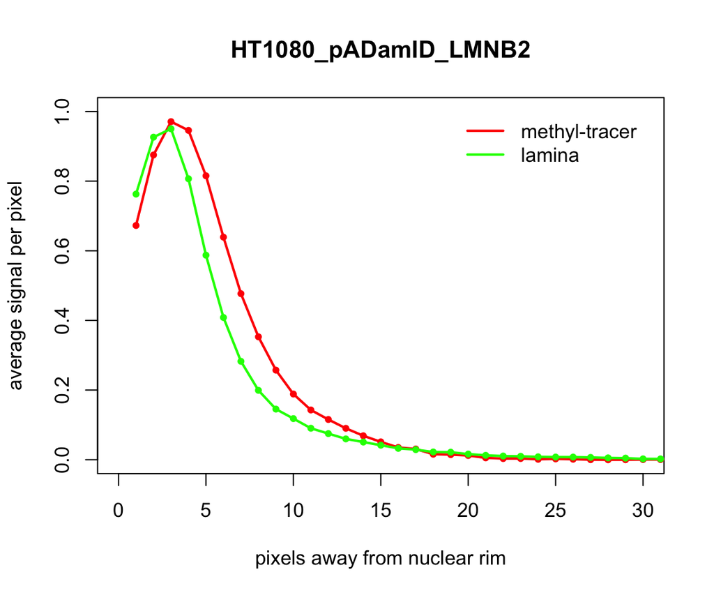

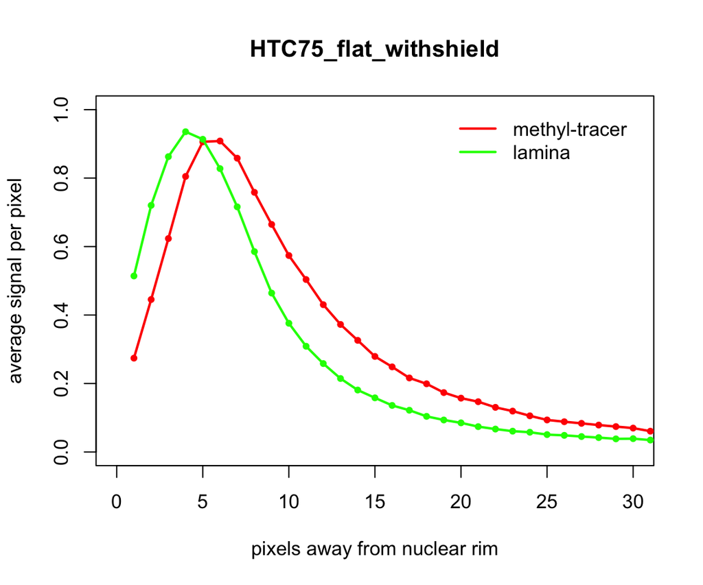

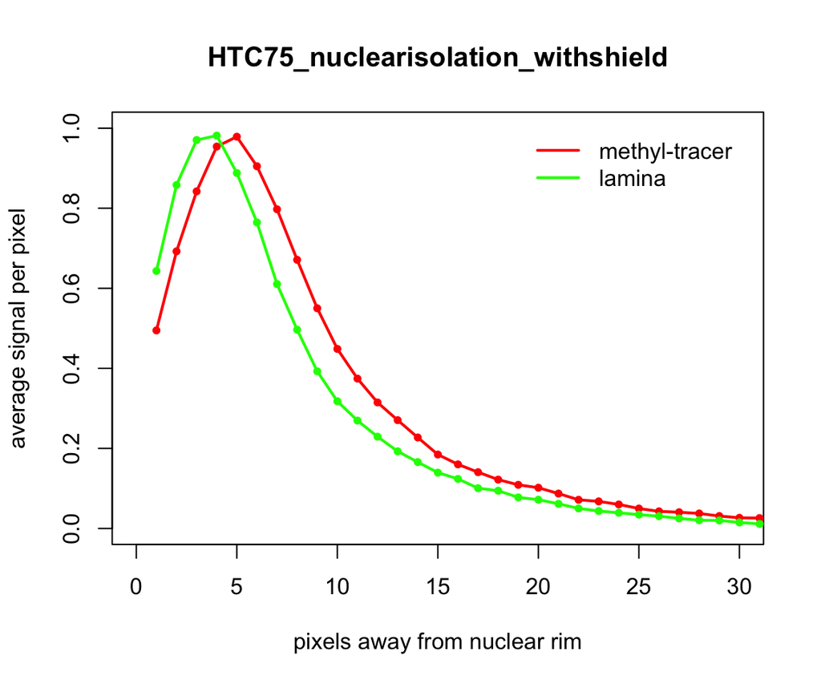

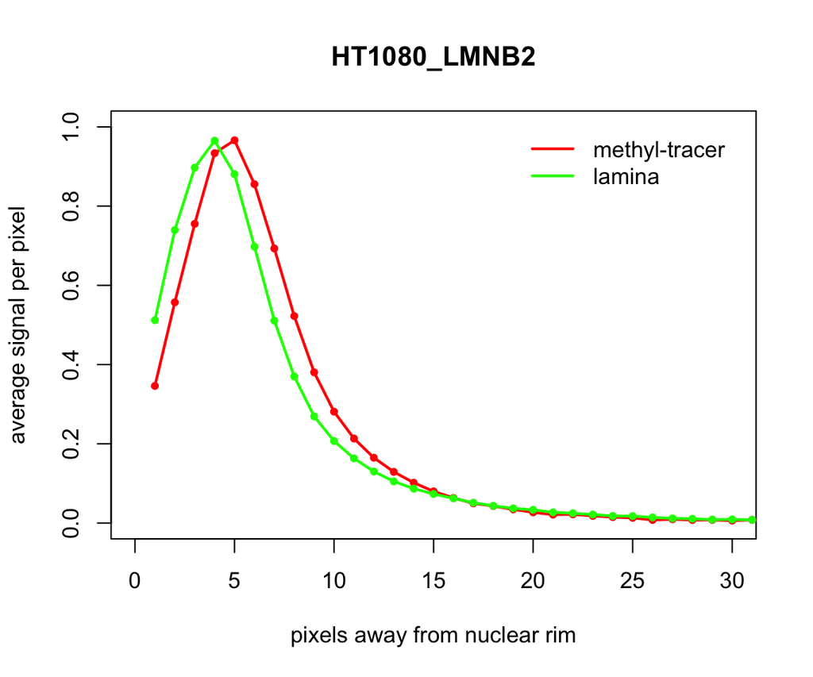

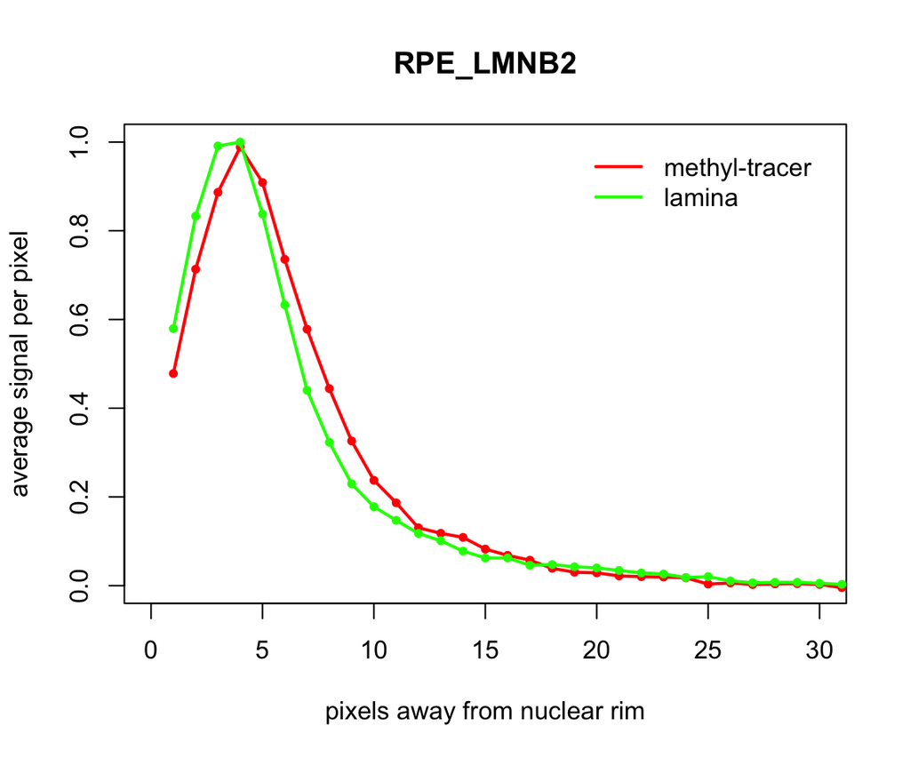

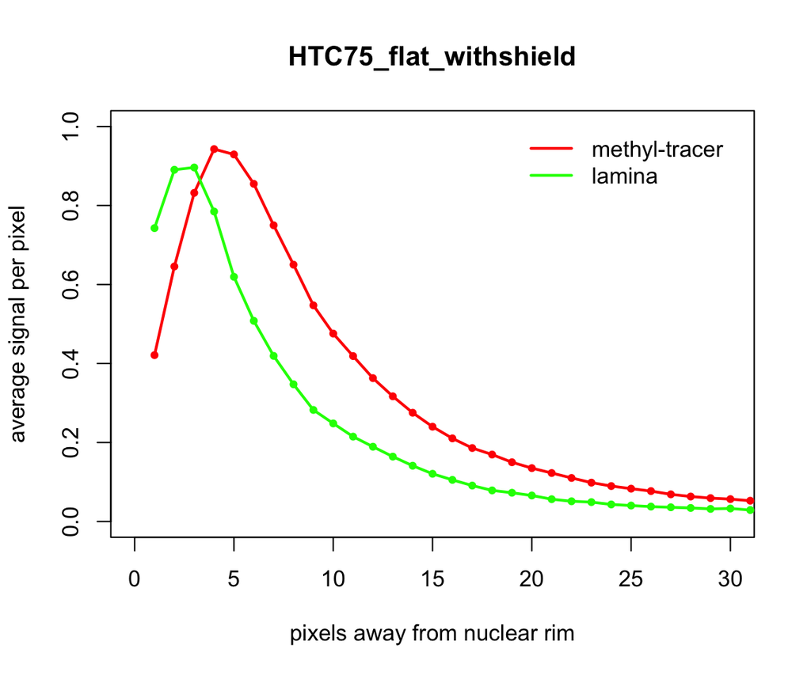

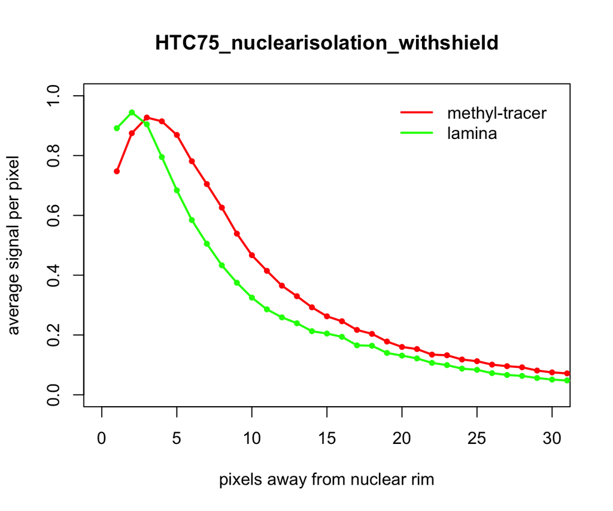

```r
# Prepare output
classes.list <- list()

for (image.path in image.paths) {

  # Get combined experiment.df
  experiments.df <- exp.res[[ image.path]][["experiments.df"]]

  # Get classes
  filter <- c("Damonly", "neg", "tryp", "withoutshield", "shield_pos")

  # classes <- unique(paste(experiments.df$cell,
  #                         experiments.df$plate,
  #                         experiments.df$target,
  #                         sep = "_"))
  classes <- unique(experiments.df$sample)
  classes <- grep(paste(filter, collapse = "|"), classes, invert = T, value = T)

  # Define range of interest
  xlim <- c(0, 30)
  df.template <- data.frame(distance = 1:xlim[2])

  for (class in classes) {

    # Get the samples for every experiment
    samples <- grep(class, experiments.df$names, value = T)
    samples.filter <- c()

    # Get signal for every pixel
    df <- data.frame(distance = c(1:xlim[2]))

    for (exp in samples) {

      if (is.null(exp.res[[ image.path]][[exp]])) {
        next
      }
      samples.filter <- c(samples.filter, exp)

      m <- exp.res[[ image.path]][[exp]][["tracer"]][["pixellayer.norm"]]
      d <- exp.res[[ image.path]][[exp]][["DAPI"]][["pixellayer.norm"]]
      l <- exp.res[[ image.path]][[exp]][["lamina"]][["pixellayer.norm"]]

      df.tmp <- data.frame(distance = names(m), m = m, l = l, d = d)
      df <- merge(df, df.tmp, by = "distance", all = T)

      names(df)[(ncol(df) - 2) : ncol(df)] <- paste0(exp, "_",
                                                     c("tracer", "lam", "dapi"))

    }

    df$distance <- as.numeric(df$distance)
    df <- df[order(df$distance), ]

    # Calculate mean signal for every pixel
    df$tracer <- rowMeans(df[, paste0(samples.filter, "_tracer")])
    df$lam <- rowMeans(df[, paste0(samples.filter, "_lam")])
    df$dapi <- rowMeans(df[, paste0(samples.filter, "_dapi")])


    # Plotting
    xlab <- 'pixels away from nuclear rim'
    ylab <- 'average signal per pixel'

    plot(NA, xlim=xlim, ylim=c(0, 1), xlab=xlab, ylab=ylab, ty='o', pch=19, lwd=2,
         main = class)
    lines(df$tracer, col='red', ty='o', pch=19, lwd=2, cex=.5)
    # lines(dapi, col='blue', ty='o', pch=19, lwd=2, cex=.5)
    lines(df$lam, col='green', ty='o', pch=19, lwd=2, cex=.5)
    # lines(x=c(-10, m.50.pix, m.50.pix), y=c(m.50, m.50, -1), lty=2, lwd=2, col='grey')
    # legend(x='topr', inset=0.025, bty='n', col=c('red', 'green', 'grey'), lwd=2, lty=c(1,1,2),
    #        legend=c('methyl-tracer', 'lamina', sprintf('half-max (pixel=%i, p50=%.4f)', m.50.pix, m.50)))
    legend(x='topr', inset=0.025, bty='n', col=c('red', 'green', 'grey'), lwd=2, lty=c(1,1,2),
         legend=c('methyl-tracer', 'lamina'))

    classes.list[[class]][["df"]] <- df

  }
}
```

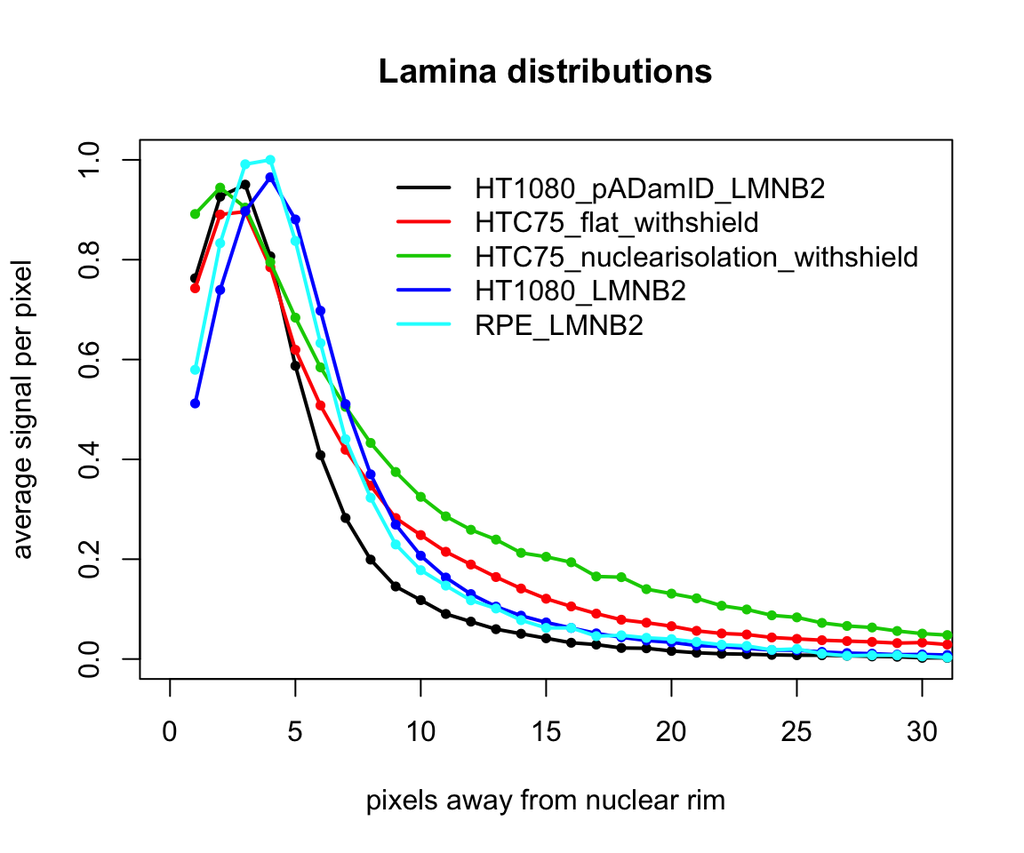

```r
# Combine lines in a single plot
classes <- names(classes.list)

# 1) Antibody
plot(NA, xlim=xlim, ylim=c(0, 1), xlab=xlab, ylab=ylab, ty='o', pch=19, lwd=2,
     main = "Lamina distributions")

for (i in seq_along(classes)) {

  class <- classes[i]
  lines(classes.list[[class]][["df"]][, "lam"], col=i, ty='o', pch=19, lwd=2, cex=.5)
}

legend(x='topright', inset=0.025, bty='n', col = 1:length(classes), lwd=2,
       legend=classes)
```

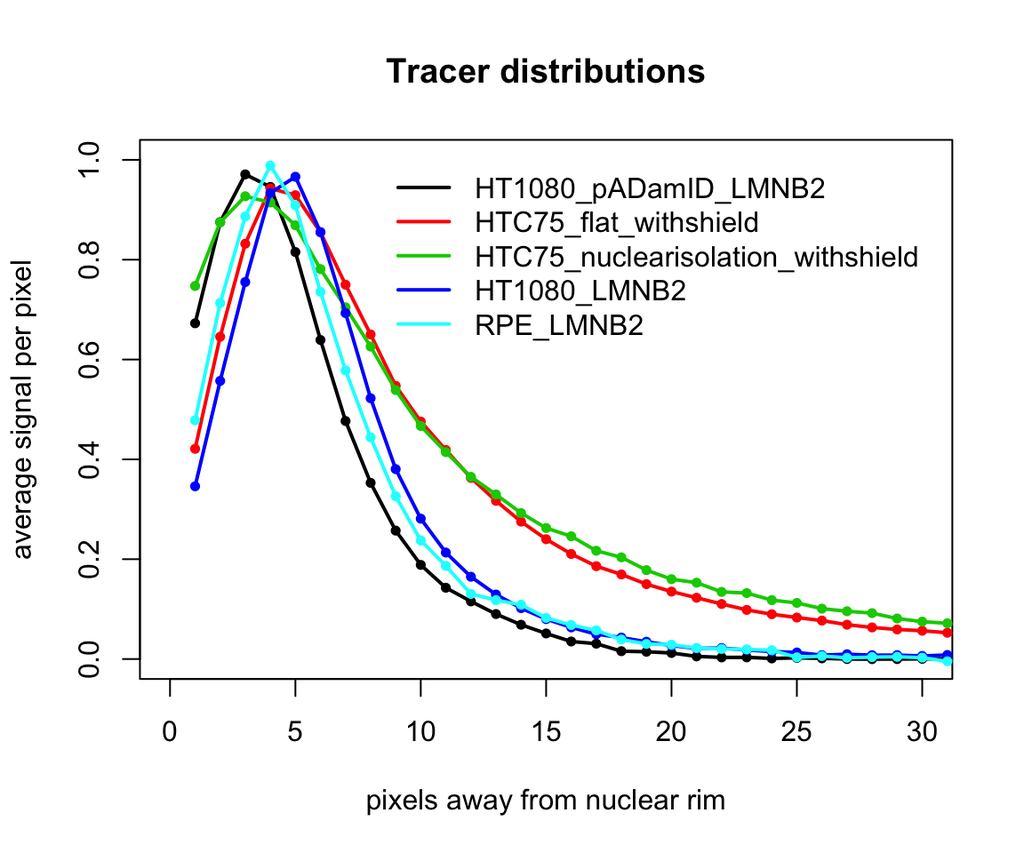

```r
# 2) Tracer
plot(NA, xlim=xlim, ylim=c(0, 1), xlab=xlab, ylab=ylab, ty='o', pch=19, lwd=2,
     main = "Tracer distributions")

for (i in seq_along(classes)) {

  class <- classes[i]
  lines(classes.list[[class]][["df"]][, "tracer"], col=i, ty='o', pch=19, lwd=2, cex=.5)
}

legend(x='topright', inset=0.025, bty='n', col = 1:length(classes), lwd=2,
       legend=classes)
```

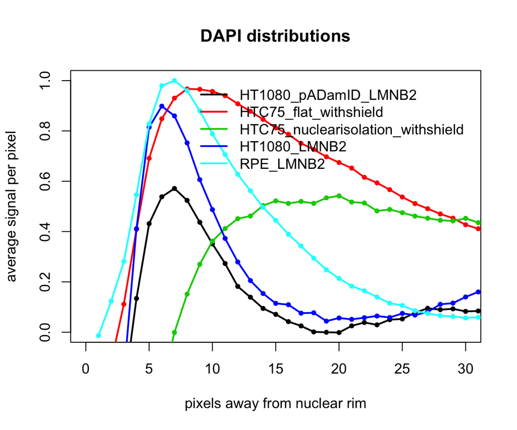

```r
# 3) DAPI
plot(NA, xlim=xlim, ylim=c(0, 1), xlab=xlab, ylab=ylab, ty='o', pch=19, lwd=2,
     main = "DAPI distributions")

for (i in seq_along(classes)) {

  class <- classes[i]
  lines(classes.list[[class]][["df"]][, "dapi"], col=i, ty='o', pch=19, lwd=2, cex=.5)
}

legend(x='topright', inset=0.025, bty='n', col = 1:length(classes), lwd=2,
       legend=classes)
```

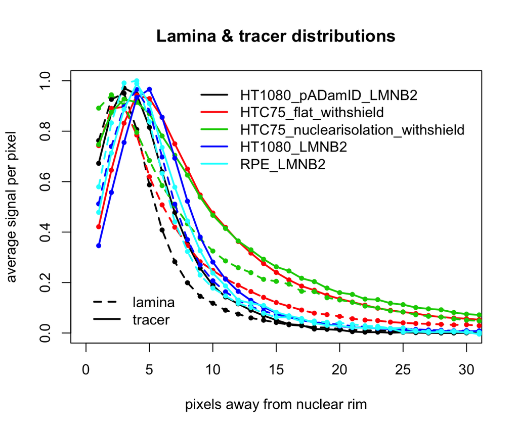

```r
# Finally, combined antibody + tracer in one figure
# Combine lines in a single plot
plot(NA, xlim=xlim, ylim=c(0, 1), xlab=xlab, ylab=ylab, ty='o', pch=19, lwd=2,
     main = "Lamina & tracer distributions")

for (i in seq_along(classes)) {

  class <- classes[i]
  lines(classes.list[[class]][["df"]][, "lam"], col=i, ty='o', pch=19, lwd=2, cex=.5, lty = 2)
  lines(classes.list[[class]][["df"]][, "tracer"], col=i, ty='o', pch=19, lwd=2, cex=.5)
}

legend(x='topright', inset=0.025, bty='n', col = 1:length(classes), lwd=2,
       legend=classes)
legend(x='bottomleft', inset=0.025, bty='n', col = 1, lwd=2, lty = c(2, 1),
       legend=c("lamina", "tracer"))
```

### Per-cell difference in m50 point

Alternatively, I can look at the difference in m50 point for the lamina and tracer, for every cell. And put these into a scatterplot.

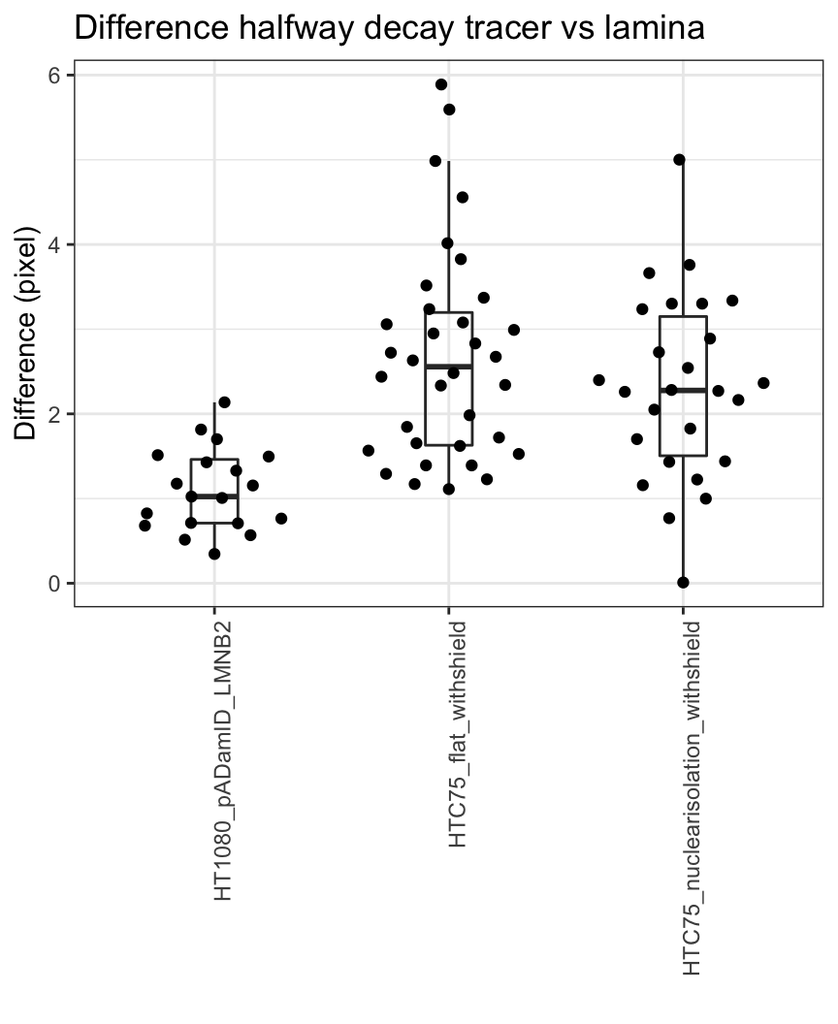

```r
d50 <- c()
classes.selection <- classes

for (class in classes.selection) {

  # Combine experiments.df
  for (image.path in image.paths) {

    # Get combined experiment.df
    experiments.df <- exp.res[[ image.path]][["experiments.df"]]

    # Get the samples for every experiment
    samples <- grep(class, experiments.df$names, value = T)

    # Get a vector of halfway points
    for (exp in samples) {

      if (is.null(exp.res[[ image.path]][[exp]])) {
        next
      }

      d50.sample <- exp.res[[ image.path]][[exp]][["halfway.scores"]][["d50.pix"]]
      l50.sample <- exp.res[[ image.path]][[exp]][["halfway.scores"]][["l.d50.pix"]]

      d50 <- rbind(d50,
                   data.frame(class = class, exp = exp,
                              d50 = d50.sample, l50 = l50.sample,
                              diff = d50.sample - l50.sample,
                              image.path = basename(image.path)))

    }
  }
}

# Manually: filter classes further
d50$class[d50$class == "HT1080_LMNB2"] <- "HT1080_pADamID_LMNB2"
d50 <- d50[d50$class != "RPE_LMNB2", ]

plt <- ggplot(d50, aes(x = class, y = diff)) +
  geom_boxplot(outlier.shape = NA, fill = NA, width = 0.2) +
  geom_quasirandom() +
  xlab("") +
  ylab("Difference (pixel)") +
  ggtitle("Difference halfway decay tracer vs lamina") +
  theme_bw() +
  theme(axis.text.x = element_text(angle = 90, hjust = 1))

plot(plt)
```

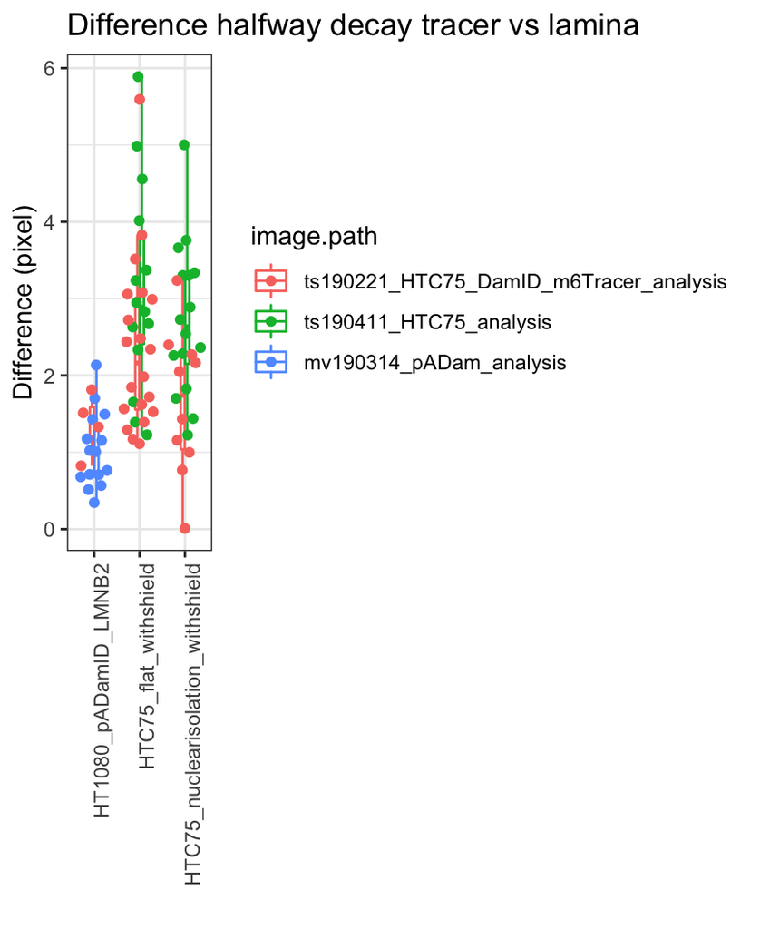

```r
plt <- ggplot(d50, aes(x = class, y = diff, col = image.path)) +
  geom_boxplot(outlier.shape = NA, fill = NA, width = 0.2) +
  geom_quasirandom() +
  xlab("") +
  ylab("Difference (pixel)") +
  ggtitle("Difference halfway decay tracer vs lamina") +
  theme_bw() +
  theme(axis.text.x = element_text(angle = 90, hjust = 1))

plot(plt)
```

### Conclusion

First of all, this needs a bit more work and a few more cells to be really reliable. Still, we can have some observations:

- The trypsin sample (very ugly cells) and the -shield sample (very little signal) are probably useless and can be disregarded for now.
- There is almost no difference between the flat cells and the nuclear isolated cells with regard to their lamina and tracer “thickness”.
- For the pA-DamID sample, we can see that the lamina and the tracer are even less thick. Especially for the lamina, I don’t know why. Most likely, we have very few cells and were a little bit more stringent in selecting useful cells. Also, the cells have less of these invaginations and lamina bridges. Coindicide or pA-DamID?
- Regardless of the thinner lamina, we can definitely say that the tracer is not thicker. If anything, it is even thinner than the shield induced sample. (Which actually makes sense, right? There are no active movements in pA- DamID.)

I think we should repeat this exercise, preferably a bit cleaner, and leave it at this.